# A TCGA dataset application

Selcen Ari

2019-11-13

# 1. Introduction

This vignette is about the integration of gene and miRNA pairs and their expression dataset and analysis. The sample dataset in this demonstration, which contains human miRNA:target pairs, was retrieved from [miRTarBase](http://mirtarbase.mbc.nctu.edu.tw/php/download.php) website (Release 7.0).

```r
library(ceRNAnetsim)
```

# 2. Installation

```r
if (!requireNamespace("BiocManager", quietly = TRUE))
    install.packages("BiocManager")
BiocManager::install("ceRNAnetsim")
```

# 3. Integration of dataset which includes only miRNA and gene expression values

## 3.1. miRNA:target pairs

```r
data("mirtarbasegene")
head(mirtarbasegene)
```

```
#> # A tibble: 6 x 2
#>   miRNA           Target
#>   <chr>           <chr>
#> 1 hsa-miR-20a-5p  HIF1A
#> 2 hsa-miR-146a-5p CXCR4
#> 3 hsa-miR-122-5p  CYP7A1
#> 4 hsa-miR-222-3p  STAT5A
#> 5 hsa-miR-21-5p   RASGRP1
#> 6 hsa-miR-148a-3p DNMT1
```

**NOTE** if the mirna:target dataset includes miRNA genes as targets, the `priming_graph()` function can fail. Because, the function define to miRNAs and targets without distinguishing between uppercase or lowercase.

## 3.2. Gene expression in normal and tumor samples

The gene and mirna expression counts of patient barcoded with TCGA-E9-A1N5 is retrieved from TCGA via `TCGAbiolinks` package (Colaprico et al. 2015) from `Bioconductor`. The instructions of retrieving data can be found at `TCGAbiolinks` manual.

For this step you don’t have to use TCGA data, any other source or package can be utilized.

```r
data("TCGA_E9_A1N5_normal")
head(TCGA_E9_A1N5_normal)
```

```
#> # A tibble: 6 x 7
#>   patient sample barcode definition ensembl_gene_id external_gene_n~
#>   <chr>   <chr>  <chr>   <chr>      <chr>           <chr>
#> 1 TCGA-E~ TCGA-~ TCGA-E~ Solid Tis~ ENSG00000000003 TSPAN6
#> 2 TCGA-E~ TCGA-~ TCGA-E~ Solid Tis~ ENSG00000000005 TNMD
#> 3 TCGA-E~ TCGA-~ TCGA-E~ Solid Tis~ ENSG00000000419 DPM1
#> 4 TCGA-E~ TCGA-~ TCGA-E~ Solid Tis~ ENSG00000000457 SCYL3
#> 5 TCGA-E~ TCGA-~ TCGA-E~ Solid Tis~ ENSG00000000460 C1orf112
#> 6 TCGA-E~ TCGA-~ TCGA-E~ Solid Tis~ ENSG00000000938 FGR
#> # ... with 1 more variable: gene_expression <dbl>
```

```r
data("TCGA_E9_A1N5_tumor")
head(TCGA_E9_A1N5_tumor)
```

```
#> # A tibble: 6 x 7
#>   patient sample barcode definition ensembl_gene_id external_gene_n~
#>   <chr>   <chr>  <chr>   <chr>      <chr>           <chr>
#> 1 TCGA-E~ TCGA-~ TCGA-E~ Primary s~ ENSG00000000003 TSPAN6
#> 2 TCGA-E~ TCGA-~ TCGA-E~ Primary s~ ENSG00000000005 TNMD
#> 3 TCGA-E~ TCGA-~ TCGA-E~ Primary s~ ENSG00000000419 DPM1
#> 4 TCGA-E~ TCGA-~ TCGA-E~ Primary s~ ENSG00000000457 SCYL3
#> 5 TCGA-E~ TCGA-~ TCGA-E~ Primary s~ ENSG00000000460 C1orf112
#> 6 TCGA-E~ TCGA-~ TCGA-E~ Primary s~ ENSG00000000938 FGR
#> # ... with 1 more variable: gene_expression <dbl>
```

## 3.3. miRNA expression data

```r
data("TCGA_E9_A1N5_mirnatumor")
head(TCGA_E9_A1N5_mirnatumor)
```

```
#> # A tibble: 6 x 6
#>   barcode             mirbase_ID   miRNA      Precusor total_read total_RPM
#>   <chr>               <chr>        <chr>      <chr>         <int>     <dbl>
#> 1 TCGA-E9-A1N5-01A-1~ MIMAT0000062 hsa-let-7~ MI00000~      45725  20802.
#> 2 TCGA-E9-A1N5-01A-1~ MIMAT0004481 hsa-let-7~ MI00000~        100     45.5
#> 3 TCGA-E9-A1N5-01A-1~ MIMAT0010195 hsa-let-7~ MI00000~          6      2.73
#> 4 TCGA-E9-A1N5-01A-1~ MIMAT0000063 hsa-let-7~ MI00000~      43489  19785.
#> 5 TCGA-E9-A1N5-01A-1~ MIMAT0004482 hsa-let-7~ MI00000~        126     57.3
#> 6 TCGA-E9-A1N5-01A-1~ MIMAT0000064 hsa-let-7~ MI00000~       2002    911.
```

```r
data("TCGA_E9_A1N5_mirnanormal")
head(TCGA_E9_A1N5_mirnanormal)
```

```
#> # A tibble: 6 x 6
#>   barcode             mirbase_ID   miRNA      Precusor total_read total_RPM
#>   <chr>               <chr>        <chr>      <chr>         <int>     <dbl>
#> 1 TCGA-E9-A1N5-11A-4~ MIMAT0000062 hsa-let-7~ MI00000~      67599   37068.
#> 2 TCGA-E9-A1N5-11A-4~ MIMAT0004481 hsa-let-7~ MI00000~        132      72.4
#> 3 TCGA-E9-A1N5-11A-4~ MIMAT0010195 hsa-let-7~ MI00000~         57      31.3
#> 4 TCGA-E9-A1N5-11A-4~ MIMAT0000063 hsa-let-7~ MI00000~      47266   25918.
#> 5 TCGA-E9-A1N5-11A-4~ MIMAT0004482 hsa-let-7~ MI00000~        126      69.1
#> 6 TCGA-E9-A1N5-11A-4~ MIMAT0000064 hsa-let-7~ MI00000~      14554    7981.
```

Here’s the summary of size of each dataset

| Dataset name | Number of rows |
| --- | --- |
| `mirtarbasegene` | 380627 |
| `TCGA_E9_A1N5_normal` | 56830 |
| `TCGA_E9_A1N5_tumor` | 56830 |
| `TCGA_E9_A1N5_mirnanormal` | 750 |
| `TCGA_E9_A1N5_mirnatumor` | 648 |

## 3.4. Integrating and analysing data

All of these datasets are integrated using the code below resulting in miRNA:target dataset that contains miRNA and gene expression values.

```r
TCGA_E9_A1N5_mirnanormal %>%
  inner_join(mirtarbasegene, by= "miRNA") %>%
  inner_join(TCGA_E9_A1N5_normal,
             by = c("Target"= "external_gene_name")) %>%
  select(Target, miRNA, total_read, gene_expression) %>%
  distinct() -> TCGA_E9_A1N5_mirnagene
```

Note: Some of genes have expression values more than one because some of tissue samples were sequenced in two medium separately. So, we select maximum expression values of that genes at following:

[output not shown]

```r
head(TCGA_E9_A1N5_mirnagene)
```

```
#> # A tibble: 6 x 4
#>   Target  miRNA         total_read gene_expression
#>   <chr>   <chr>              <int>           <dbl>
#> 1 CDK6    hsa-let-7a-5p      67599            4669
#> 2 MYC     hsa-let-7a-5p      67599           11593
#> 3 BCL2    hsa-let-7a-5p      67599            2445
#> 4 NKIRAS2 hsa-let-7a-5p      67599            1519
#> 5 ITGB3   hsa-let-7a-5p      67599             196
#> 6 NF2     hsa-let-7a-5p      67599            1755
```

When we compared the two gene expression dataset of TCGA-E9A1N5 patient, and selected a gene which has 30-fold increased expression, (gene name: HIST1H3H), this gene node will be used in the example. Note that the selected node must not be isolated one. If the an isolated node is selected the change in expression will not propagate in network. (You can see commands for node selection in the vignette [The auxiliary commands which can help to the users](https://selcenari.github.io/ceRNAnetsim/articles/auxiliary_commands.html))

Optionally, you can filter the low expressed gene nodes because they are not effective elements.

```r
TCGA_E9_A1N5_mirnagene%>%
  filter(gene_expression > 10)->TCGA_E9_A1N5_mirnagene
```

The analysis is performed based on amounts of miRNAs and targets as seen. Firstly, we tried to find optimal iteration for the network when simulation start with *HIST1H3H* node.

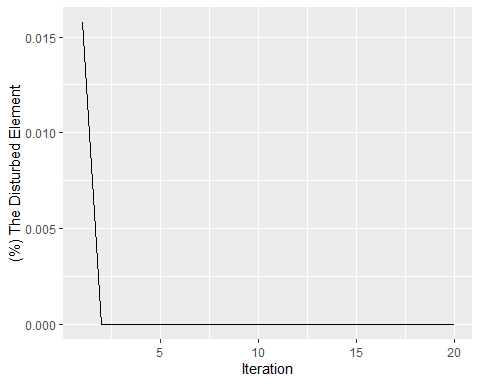

Perturbation of HIST1H3H gene on each iteration

```r
TCGA_E9_A1N5_mirnagene %>%
  priming_graph(competing_count = gene_expression,
                miRNA_count = total_read) %>%
  update_how(node_name = "HIST1H3H", how =30) %>%
  simulate(20) %>%
  find_iteration(plot=TRUE)
```

The graph was shown that the change in expression level of HIST1H3H results in weak perturbation efficiency, despite 30-fold change. The code shown below can be used for calculation of fold changes after simulation HIST1H3H gene to 30 fold:

```r
TCGA_E9_A1N5_mirnagene %>%
  priming_graph(competing_count = gene_expression,
                miRNA_count = total_read) %>%
  update_how("HIST1H3H", 30) %>%
  simulate(20)%>%
  as_tibble()%>%
  mutate(FC= count_current/initial_count)%>%
  arrange(desc(FC))
```

Also, perturbation calculation (specifies efficiency of selected node) of HIST1H3H gene

```r
TCGA_E9_A1N5_mirnagene %>%
  priming_graph(competing_count = gene_expression,
                miRNA_count = total_read)%>%
  calc_perturbation(node_name= "HIST1H3H", cycle=20, how= 30,limit = 0.1)
```

| *perturbation_efficiency* | *perturbed_count* |
| --- | --- |
| 4.930245e-06 | 0 |

And then, we tried to simulate the network with the gene which has higher expression value. For this, we selected *ACTB* node as shown in [The auxiliary commands which can help to the users](https://selcenari.github.io/ceRNAnetsim/articles/auxiliary_commands.html)

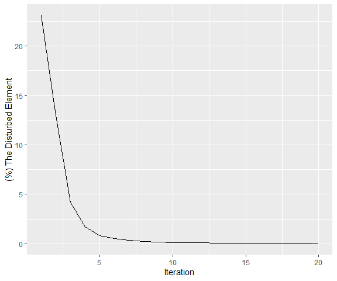

Perturbation of ACTB gene on each iteration

```r
TCGA_E9_A1N5_mirnagene %>%
  priming_graph(competing_count = gene_expression,
                miRNA_count = total_read) %>%
  update_how(node_name = "ACTB", how =1.87) %>%
  simulate(20) %>%
  find_iteration(plot=TRUE)
```

Following codes are shown entire gene fold changes after simulation ACTB gene to 1.87 fold:

```r
TCGA_E9_A1N5_mirnagene %>%
  priming_graph(competing_count = gene_expression,
                miRNA_count = total_read) %>%
  update_how("ACTB", 1.87) %>%
  simulate(20)%>%
  as_tibble()%>%
  mutate(FC= count_current/initial_count)%>%
  arrange(desc(FC))
```

```r
TCGA_E9_A1N5_mirnagene %>%
  priming_graph(competing_count = gene_expression,
                miRNA_count = total_read)%>%
  calc_perturbation(node_name= "ACTB", cycle=20, how= 1.87,limit = 0.1)
```

| *perturbation_efficiency* | *perturbed_count* |
| --- | --- |
| 0.01548928 | 826 |

On the other hand, the perturbation eficiency of ATCB gene is higher, when this gene is regulated with 30-fold upregulation like in HIST1H3H.

```r
TCGA_E9_A1N5_mirnagene %>%
  priming_graph(competing_count = gene_expression,
                miRNA_count = total_read)%>%
  calc_perturbation(node_name= "ACTB", cycle=20, how= 30,limit = 0.1)
```

| *perturbation_efficiency* | *perturbed_count* |
| --- | --- |
| 0.2094567 | 3712 |

## 3.5. The sum of two conditions:

In a real biological sample, we tested perturbation efficiencies of two genes; * one with low expression but high fold change (HIST1H3H, 30-fold increase in tumor) * another one with high expression but small change in expression level (ACTB, 1.87-fold increase in tumor)

With these two samples, it has been obtained that expression values of genes, rest of the perturbed gene, changed slightly.

Despite high fold change, former gene caused little perturbation. When the perturbation efficiencies of both of these genes are analysed, it has been oberved that HIST1H3H does not affect the other genes in given limit. On the contrary, high expressing gene with very low fold increase in tumor causes greater perturbation in the network. Additionaly, the perturbation efficiency of ACTB gene is quite high from HIST1H3H with 30-fold change, when ACTB is simulated with 30 fold-change.

Thus, if the perturbed node has lower target:total target ratio in group or groups, the efficiency of it can be weak, or vice versa. The efficiency of ACTB gene may be high for this reason, in comparison with HIST1H3H perturbation. In fact, it has been observed that ACTB has not strong perturbation efficiency too. This could be arisen from low miRNA:target ratio or ineffective target nodes which have very low expression levels.

# 4. Dataset (`huge_example`) which includes miRNA and gene expressions and miRNA:target interaction factors

## 4.1. Description of the *huge_example* dataset

Interactions between miRNAs and their targets can be analyzed after the integration of miRNA and targets via various datasets. As an example, we prepared the *huge_example* dataset. It was generated by integrating:

- Next-generation RNA sequencing data of a breast cancer patient from TCGA (patient id:TCGA_A7_A0CE)
- The microRNA expression values of the same breast cancer patient.
- High-throughput miRNA:target determination datasets. We utilised the microRNA:target gene dataset which was integrated from high-throughput experimental studies([CLASH](https://www.ncbi.nlm.nih.gov/pmc/articles/PMC3650559/) & [CLEAR-CLiP](https://www.nature.com/articles/ncomms9864) methods). These datasets give exact microRNA:target pairs because of these methods base on chimeric reading of pairs after binding of microRNAs and their targets. For this reason, the datasets contain detailed information for microRNA:target pairs such as interacted bases (in terms of degree of complementarity) on microRNAs and target mRNAs, location of interaction region (seed) on mRNA and estimated binding energies of pairs.

Below, only 6 rows from total of 26,176 rows are shown.

```r
data("huge_example")
head(huge_example)
```

```
#>   competing           miRNA competing_counts mirnaexpression_normal Energy
#> 1    TSPAN6     hsa-miR-484             5404              23.058807  -21.4
#> 2      DPM1  hsa-miR-18b-5p             2472               0.256209  -10.0
#> 3     SCYL3  hsa-miR-149-5p             1483              34.844420   -5.5
#> 4     SCYL3  hsa-miR-30a-5p             1483           63031.505507  -13.0
#> 5  C1orf112 hsa-miR-1296-5p              312               1.793463   -8.1
#> 6       CFH   hsa-miR-17-5p             5760              89.929349  -17.2
#>   region_effect seed_type_effect
#> 1          0.42             0.43
#> 2          0.84             0.01
#> 3          0.42             0.01
#> 4          0.84             0.43
#> 5          0.42             0.01
#> 6          0.42             0.01
```

## 4.2. Select a node as trigger

The node that initiates simulation can be determined according your interest or research.

The dataset, which is a data frame, can be manipulated with [tidyverse packages](https://www.tidyverse.org/packages/). As an example, competing RNAs targeted by less than 5 miRNAs are eliminated to make the network manageable size.

```r
huge_example %>%
  add_count(competing) %>%
  filter(n > 5) %>%
  select(-n) -> filtered_example

head(filtered_example)
```

```
#> # A tibble: 6 x 7
#>   competing miRNA competing_counts mirnaexpression~ Energy region_effect
#>   <chr>     <chr>            <dbl>            <dbl>  <dbl>         <dbl>
#> 1 MAD1L1    hsa-~             1909             34.8  -18.6          0.42
#> 2 MAD1L1    hsa-~             1909            297.   -19.3          0.01
#> 3 MAD1L1    hsa-~             1909             55.9  -15.4          0.01
#> 4 MAD1L1    hsa-~             1909             65.8  -13.6          0.42
#> 5 MAD1L1    hsa-~             1909            603.   -26.7          0.01
#> 6 MAD1L1    hsa-~             1909           5113.   -30.6          0.01
#> # ... with 1 more variable: seed_type_effect <dbl>
```

On the other hand, we chose the node *GAPDH* according to interaction count of the nodes. With the simulation, the graph was visualized after node *GAPDH* was increased to five fold.

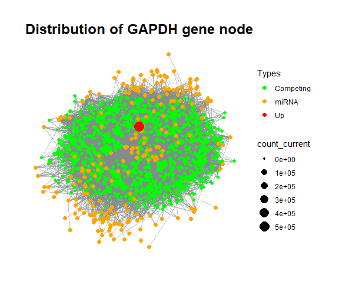

Distribution of GAPDH gene node

```r
filtered_example %>%
  priming_graph(competing_count = competing_counts,
                miRNA_count = mirnaexpression_normal,
                aff_factor = Energy) %>%
  update_how("GAPDH", 5) %>%
  vis_graph(title = "Distribution of GAPDH gene node")
```

Let’s visualize each step of simulation via `simulate_vis()` function.

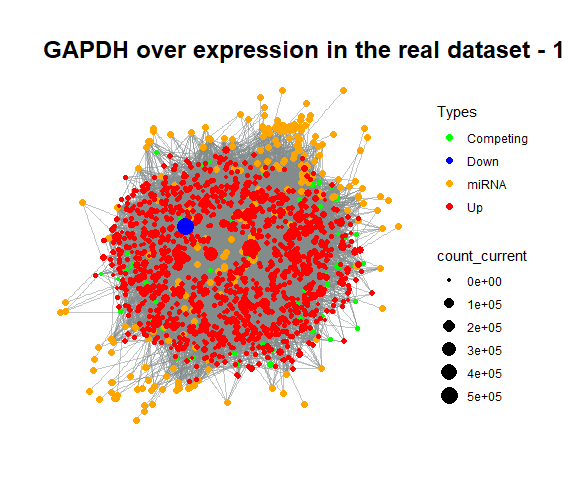

GAPDH over expression in real dataset

```r
filtered_example %>%
  priming_graph(competing_count = competing_counts,
                miRNA_count = mirnaexpression_normal,
                aff_factor = Energy) %>%
  update_how("GAPDH", 5) %>%
  simulate_vis(title = "GAPDH over expression in the real dataset", 3)
```

Now, we can track changes in expression levels at every node for 3 cycles when GAPDH is overexpressed 5-fold.

# 5. Finding perturbation efficiency on an experimental dataset

In real biological datasets, more complex interactions whether functional or non-functional could be observed. We have improved our approach with `fast` argument in `find_node_perturbation()` based on selection of elements that could be affected from perturbation. In this fucntion, `fast` argument specifies the percentage of the competing amount that can be affected within the initial competing amount and acts as a selection parameter. For instance, in huge_example data:

```r
huge_example%>%
  priming_graph(competing_count = competing_counts, miRNA_count = mirnaexpression_normal)%>%
  find_node_perturbation(how=5, cycle=3, fast = 3)%>%
  select(name, perturbation_efficiency, perturbed_count)
```

```r
huge_example%>%
  priming_graph(competing_count = competing_counts, miRNA_count = mirnaexpression_normal)%>%
  find_node_perturbation(how=5, cycle=3, fast = 3)%>%
  filter(!is.na(perturbation_efficiency), !is.na(perturbed_count))%>%
  select(name, perturbation_efficiency, perturbed_count)
```

| *name* | *perturbation_efficiency* | *perturbed_count* |
| --- | --- | --- |
| AK2 | 7.938457e-02 | 542 |
| SLC25A5 | 1.540258e-01 | 542 |
| MSL3 | 3.241137e-02 | 542 |
| MYCBP2 | 3.141119e-02 | 514 |
| VPS41 | 2.116591e-02 | 514 |
| ADIPOR2 | 8.039431e-02 | 542 |
| CELSR3 | 2.220963e-03 | 542 |
| SCMH1 | 4.186803e-02 | 542 |
| EXTL3 | 4.015119e-02 | 542 |
| NR1H4 | 1.033477e-05 | 542 |

## References

Colaprico, Antonio, Tiago C Silva, Catharina Olsen, Luciano Garofano, Claudia Cava, Davide Garolini, Thais S Sabedot, et al. 2015. “TCGAbiolinks: An R/Bioconductor Package for Integrative Analysis of Tcga Data.” *Nucleic Acids Research* 44 (8): e71–e71.